# New York Taxi Time Predictions

# By : Rishit Dholakia

This is a challenge in which the new York taxi trip duration is to be predicted by the user . This is a form of *predictive modelling*. It requires the following *feature engineering, data cleaning , analysis of the data, training and prediction*

## Importing Dataset

We first import the dataset for the training and test consisting of 14 lakh and 6 lakh respectively

```r
library(data.table)
train <- fread("train.csv")
```

```
Read 21.9% of 1458644 rows
Read 35.6% of 1458644 rows
Read 48.7% of 1458644 rows
Read 61.7% of 1458644 rows
Read 75.4% of 1458644 rows
Read 89.1% of 1458644 rows
Read 1458644 rows and 11 (of 11) columns from 0.187 GB file in 00:00:09
```

```r
test_csv <- fread("test.csv")
```

```
Read 65.6% of 625134 rows
Read 625134 rows and 9 (of 9) columns from 0.066 GB file in 00:00:04
```

```r
head(train)
```

| id | vendor_id | pickup_datetime | dropoff_datetime | passenger_count | pickup_longitude | pickup_latitude | dropoff_longitude | dropoff_latitude | store_and_fwd_flag | trip_duration |
| --- | --- | --- | --- | --- | --- | --- | --- | --- | --- | --- |
| id2875421 | 2 | 2016-03-14 17:24:55 | 2016-03-14 17:32:30 | 1 | -73.98215 | 40.76794 | -73.96463 | 40.76560 | N | 455 |
| id2377394 | 1 | 2016-06-12 00:43:35 | 2016-06-12 00:54:38 | 1 | -73.98042 | 40.73856 | -73.99948 | 40.73115 | N | 663 |
| id3858529 | 2 | 2016-01-19 11:35:24 | 2016-01-19 12:10:48 | 1 | -73.97903 | 40.76394 | -74.00533 | 40.71009 | N | 2124 |
| id3504673 | 2 | 2016-04-06 19:32:31 | 2016-04-06 19:39:40 | 1 | -74.01004 | 40.71997 | -74.01227 | 40.70672 | N | 429 |
| id2181028 | 2 | 2016-03-26 13:30:55 | 2016-03-26 13:38:10 | 1 | -73.97305 | 40.79321 | -73.97292 | 40.78252 | N | 435 |
| id0801584 | 2 | 2016-01-30 22:01:40 | 2016-01-30 22:09:03 | 6 | -73.98286 | 40.74220 | -73.99208 | 40.74918 | N | 443 |

```r
summary(train)
```

```
      id              vendor_id     pickup_datetime
 Length:1458644     Min.   :1.000   Length:1458644
 Class :character   1st Qu.:1.000   Class :character
 Mode  :character   Median :2.000   Mode  :character
                    Mean   :1.535
                    3rd Qu.:2.000
                    Max.   :2.000
 dropoff_datetime   passenger_count pickup_longitude
 Length:1458644     Min.   :0.000   Min.   :-121.93
 Class :character   1st Qu.:1.000   1st Qu.: -73.99
 Mode  :character   Median :1.000   Median : -73.98
                    Mean   :1.665   Mean   : -73.97
                    3rd Qu.:2.000   3rd Qu.: -73.97
                    Max.   :9.000   Max.   : -61.34
 pickup_latitude dropoff_longitude dropoff_latitude
 Min.   :34.36   Min.   :-121.93   Min.   :32.18
 1st Qu.:40.74   1st Qu.: -73.99   1st Qu.:40.74
 Median :40.75   Median : -73.98   Median :40.75
 Mean   :40.75   Mean   : -73.97   Mean   :40.75
 3rd Qu.:40.77   3rd Qu.: -73.96   3rd Qu.:40.77
 Max.   :51.88   Max.   : -61.34   Max.   :43.92
 store_and_fwd_flag trip_duration
 Length:1458644     Min.   :      1
 Class :character   1st Qu.:    397
 Mode  :character   Median :    662
                    Mean   :    959
                    3rd Qu.:   1075
                    Max.   :3526282
```

TO BE NOTED : Before we get into feature engineering we need to first clear up the existing data and make the features much more useful to view . So that we can apply the preprocessing techniques .

## Concatenation

In this we concatenate the training and the test set as if any of the changes are applied in the features it will be affected both in one go. We notice that there is a difference in the number of columns in training and test and those are adjusted in the following code.

```r
col_train <- colnames(train)
col_test <- colnames(test_csv)
col_train[!col_train %in% col_test]
```

```
[1] "dropoff_datetime" "trip_duration"
```

```r
train$dropoff_datetime <- NULL
test.trip_duration <- data.frame(test_csv[],trip_duration = rep("None",nrow(test_csv)))
datanew <- rbind(train,test.trip_duration)
str(datanew)
```

```
Classes data.table and 'data.frame':  2083778 obs. of  10 variables:
 $ id                : chr  "id2875421" "id2377394" "id3858529" "id3504673" ...
 $ vendor_id         : int  2 1 2 2 2 2 1 2 1 2 ...
 $ pickup_datetime   : chr  "2016-03-14 17:24:55" "2016-06-12 00:43:35" "2016-01-19 11:35:24" "2016-04-06 19:32:31" ...
 $ passenger_count   : int  1 1 1 1 1 6 4 1 1 1 ...
 $ pickup_longitude  : num  -74 -74 -74 -74 -74 ...
 $ pickup_latitude   : num  40.8 40.7 40.8 40.7 40.8 ...
 $ dropoff_longitude : num  -74 -74 -74 -74 -74 ...
 $ dropoff_latitude  : num  40.8 40.7 40.7 40.7 40.8 ...
 $ store_and_fwd_flag: chr  "N" "N" "N" "N" ...
 $ trip_duration     : Factor w/ 7418 levels "455","663","2124",..: 1 2 3 4 5 6 7 8 9 10 ...
 - attr(*, ".internal.selfref")=<externalptr>
```

Visualizing the format of the date

```r
head(datanew$pickup_datetime)
```

```
[1] "2016-03-14 17:24:55" "2016-06-12 00:43:35"
[3] "2016-01-19 11:35:24" "2016-04-06 19:32:31"
[5] "2016-03-26 13:30:55" "2016-01-30 22:01:40"
```

We now pre-process this by splitting the date and the time.

[output not shown]

# Renaming and adding of the hour columns

Now that we have names of the new columns as V1 and V2 we have to rename them. there is addition of the hour column also in this. To make it simplify the complexity of the code.

```r
library(data.table)
setnames(datanew1,"V1","pickup_date")
setnames(datanew1,"V2","pickup_time")
datanew1$pickup_date<-as.character(datanew1$pickup_date)
datanew1$pickup_time<-as.character(datanew1$pickup_time)
str(datanew1)
```

```
Classes data.table and 'data.frame':  2083778 obs. of  12 variables:
 $ id                : chr  "id2875421" "id2377394" "id3858529" "id3504673" ...
 $ vendor_id         : int  2 1 2 2 2 2 1 2 1 2 ...
 $ pickup_datetime   : chr  "2016-03-14 17:24:55" "2016-06-12 00:43:35" "2016-01-19 11:35:24" "2016-04-06 19:32:31" ...
 $ passenger_count   : int  1 1 1 1 1 6 4 1 1 1 ...
 $ pickup_longitude  : num  -74 -74 -74 -74 -74 ...
 $ pickup_latitude   : num  40.8 40.7 40.8 40.7 40.8 ...
 $ dropoff_longitude : num  -74 -74 -74 -74 -74 ...
 $ dropoff_latitude  : num  40.8 40.7 40.7 40.7 40.8 ...
 $ store_and_fwd_flag: chr  "N" "N" "N" "N" ...
 $ trip_duration     : Factor w/ 7418 levels "455","663","2124",..: 1 2 3 4 5 6 7 8 9 10 ...
 $ pickup_date       : chr  "2016-03-14" "2016-06-12" "2016-01-19" "2016-04-06" ...
 $ pickup_time       : chr  "17:24:55" "00:43:35" "11:35:24" "19:32:31" ...
 - attr(*, ".internal.selfref")=<externalptr>
```

| id | vendor_id | passenger_count | pickup_longitude | pickup_latitude | dropoff_longitude | dropoff_latitude | store_and_fwd_flag | trip_duration | pickup_date | pickup_time | time_hr |
| --- | --- | --- | --- | --- | --- | --- | --- | --- | --- | --- | --- |
| id2875421 | 2 | 1 | -73.98215 | 40.76794 | -73.96463 | 40.76560 | N | 455 | 2016-03-14 | 17:24:55 | 17 |
| id2377394 | 1 | 1 | -73.98042 | 40.73856 | -73.99948 | 40.73115 | N | 663 | 2016-06-12 | 00:43:35 | 00 |
| id3858529 | 2 | 1 | -73.97903 | 40.76394 | -74.00533 | 40.71009 | N | 2124 | 2016-01-19 | 11:35:24 | 11 |
| id3504673 | 2 | 1 | -74.01004 | 40.71997 | -74.01227 | 40.70672 | N | 429 | 2016-04-06 | 19:32:31 | 19 |
| id2181028 | 2 | 1 | -73.97305 | 40.79321 | -73.97292 | 40.78252 | N | 435 | 2016-03-26 | 13:30:55 | 13 |
| id0801584 | 2 | 6 | -73.98286 | 40.74220 | -73.99208 | 40.74918 | N | 443 | 2016-01-30 | 22:01:40 | 22 |

# Training benchmark on the current features and testing the working of the model

Before we add additional features , the benchmark of the RMSE value is going to be used in order to get an idea on the prediction that is need for the further analysis of the feature .Since the dataset is large , artificial neural networks is a good algorithm to train the models.the H20.ai api is used in order to cluster up the data for faster processing.

```r
library(h2o)
h2o.init(nthreads = 3)
datanew2$pickup_time <- NULL
datanew2$trip_duration=as.numeric(datanew2$trip_duration)
train.h20<-as.h2o(datanew2[1:1458644,])
train.h20$vendor_id<-as.factor(train.h20$vendor_id)
train.h20$store_and_fwd_flag<-as.factor(train.h20$store_and_fwd_flag)

model = h2o.deeplearning(x=c(2,3,4,5,6,7,8),y = 9,
                         training_frame = as.h2o(train.h20),
                         activation = 'Rectifier',
                         hidden = c(100,100),
                         epochs = 100
                         )
```

```r
print(model)
```

```
Model Details:
==============

H2ORegressionModel: deeplearning
Model ID:  DeepLearning_model_R_1516486131716_1
Status of Neuron Layers: predicting trip_duration, regression, gaussian distribution, Quadratic loss, 11,401 weights/biases, 140.3 KB, 7,197,991 training samples, mini-batch size 1
  layer units      type dropout       l1       l2 mean_rate
1     1    11     Input  0.00 %
2     2   100 Rectifier  0.00 % 0.000000 0.000000  0.184861
3     3   100 Rectifier  0.00 % 0.000000 0.000000  0.108016
4     4     1    Linear         0.000000 0.000000  0.001333
  rate_rms momentum mean_weight weight_rms mean_bias bias_rms
1
2 0.391947 0.000000   -0.020045   0.463850  0.237314 0.359725
3 0.143376 0.000000   -0.053494   0.190211  0.812243 0.243344
4 0.001728 0.000000    0.009956   0.053232  0.050364 0.000000


H2ORegressionMetrics: deeplearning
** Reported on training data. **
** Metrics reported on temporary training frame with 10011 samples **

MSE:  473306.2
RMSE:  687.9725
MAE:  521.6033
RMSLE:  1.073164
Mean Residual Deviance :  473306.2
```

Since the value of RMSLE value is more than 1 . There is a need for feature engineering and analysis.

Soo lets head on to that !!!!!!!!!!

## Feature Engineering and Data cleaning based on the analysis of data

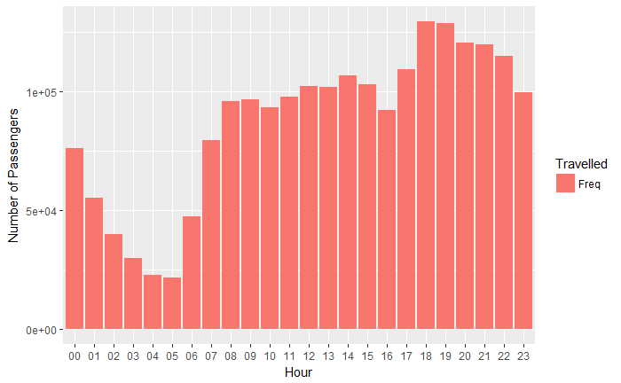

```r
library(ggplot2)
a<-as.data.frame(datanew2)
ggplot(a,aes(x=as.factor(time_hr),fill="Freq"))+geom_bar()+xlab("Hour")+ylab("Number of Passengers")+labs(fill="Travelled")
```

# Add a new feature of the sessions of a day

The interesting fact that we can do based on the visualization above is that we can break the day into morning,evening,night etc based on the hours of the day !!!!! Lets impliment this piece of code .

Categorizing time into early morning, morning, afternoon, evening, night, late night 03-07 : Early morning, 08-11 : Morning, 12-15 : Afternoon, 16-19 : Evening, 20-22 , Night, 23-02: Late Night

```r
library(data.table)
time_day <- as.data.frame(as.numeric(datanew2$time_hr))
setnames(time_day,"as.numeric(datanew2$time_hr)","time_hrs")
time_mod2 <- data.frame(time_day= rep("None",nrow(datanew2)))
time_mod2$time_day <- as.character(time_mod2$time_day)
time_mod2$time_day[which(time_day$time_hr>=8 & time_day$time_hr <=11)] <- as.character("M")
time_mod2$time_day[which(time_day$time_hr>=12 & time_day$time_hr <=15)] <- as.character("A")
time_mod2$time_day[which(time_day$time_hr>=16 & time_day$time_hr <=19)] <- as.character("E")
time_mod2$time_day[which(time_day$time_hr>=20 & time_day$time_hr <=22)] <- as.character("N")
time_mod2$time_day[which(time_day$time_hr>=23)] <- as.character("LN")
time_mod2$time_day[which(time_day$time_hr <=2)] <- as.character("LN")
time_mod2$time_day[which(time_day$time_hr>=3 & time_day$time_hr <=7)] <- as.character("EM")
datanew2<-cbind(datanew2,time_mod2)
datanew2$time_hr<-NULL
```

We view it and check the summary of this piece of code. *note*:- we can remove the hours column as the sessions feature has helped in the better resolution and understanding by the program .

```r
summary(datanew2)
```

```
      id              vendor_id     passenger_count
 Length:2083778     Min.   :1.000   Min.   :0.000
 Class :character   1st Qu.:1.000   1st Qu.:1.000
 Mode  :character   Median :2.000   Median :1.000
                    Mean   :1.535   Mean   :1.664
                    3rd Qu.:2.000   3rd Qu.:2.000
                    Max.   :2.000   Max.   :9.000
 pickup_longitude  pickup_latitude dropoff_longitude
 Min.   :-121.93   Min.   :34.36   Min.   :-121.93
 1st Qu.: -73.99   1st Qu.:40.74   1st Qu.: -73.99
 Median : -73.98   Median :40.75   Median : -73.98
 Mean   : -73.97   Mean   :40.75   Mean   : -73.97
 3rd Qu.: -73.97   3rd Qu.:40.77   3rd Qu.: -73.96
 Max.   : -61.34   Max.   :51.88   Max.   : -61.34
 dropoff_latitude store_and_fwd_flag trip_duration
 Min.   :32.18    Length:2083778     Min.   :   1
 1st Qu.:40.74    Class :character   1st Qu.: 583
 Median :40.75    Mode  :character   Median :1307
 Mean   :40.75                       Mean   :2932
 3rd Qu.:40.77                       3rd Qu.:7418
 Max.   :48.86                       Max.   :7418
  pickup_date           time_day
 Min.   :2016-01-01   Length:2083778
 1st Qu.:2016-02-17   Class :character
 Median :2016-04-01   Mode  :character
 Mean   :2016-03-31
 3rd Qu.:2016-05-15
 Max.   :2016-06-30
```

```r
head(datanew2)
```

| id | vendor_id | passenger_count | pickup_longitude | pickup_latitude | dropoff_longitude | dropoff_latitude | store_and_fwd_flag | trip_duration | pickup_date | time_day |
| --- | --- | --- | --- | --- | --- | --- | --- | --- | --- | --- |
| id2875421 | 2 | 1 | -73.98215 | 40.76794 | -73.96463 | 40.76560 | N | 1 | 2016-03-14 | E |
| id2377394 | 1 | 1 | -73.98042 | 40.73856 | -73.99948 | 40.73115 | N | 2 | 2016-06-12 | LN |
| id3858529 | 2 | 1 | -73.97903 | 40.76394 | -74.00533 | 40.71009 | N | 3 | 2016-01-19 | A |
| id3504673 | 2 | 1 | -74.01004 | 40.71997 | -74.01227 | 40.70672 | N | 4 | 2016-04-06 | N |
| id2181028 | 2 | 1 | -73.97305 | 40.79321 | -73.97292 | 40.78252 | N | 5 | 2016-03-26 | A |
| id0801584 | 2 | 6 | -73.98286 | 40.74220 | -73.99208 | 40.74918 | N | 6 | 2016-01-30 | LN |

# Scaling of the data

Now this is one important criteria as this will help in gradient decent effectively.

```r
datanew2$passenger_count<-scale(datanew2$passenger_count)
datanew2$pickup_longitude<-scale(datanew2$pickup_longitude)
datanew2$pickup_latitude<-scale(datanew2$pickup_latitude)
datanew2$dropoff_longitude<-scale(datanew2$dropoff_longitude)
datanew2$dropoff_latitude<-scale(datanew2$dropoff_latitude)
head(datanew2)
```

[output not shown]

# Adding distance feature column

This is the most important feature as it playes a major role in this feture engineering . We do this using a library called geosphere.

```r
library(geosphere)
datanew2$distance <- distHaversine(datanew1[,5:6], datanew1[,7:8])/1000
summary(datanew2$distance[which(datanew2$trip_duration<5)])
```

```
   Min. 1st Qu.  Median    Mean 3rd Qu.    Max.
  0.000   1.224   1.655   2.013   2.283  27.400
```

```r
library(ggplot2)
summary(datanew2$trip_duration)
```

```
   Min. 1st Qu.  Median    Mean 3rd Qu.    Max.
      1     583    1307    2932    7418    7418
```

```r
summary(datanew2$distance)
```

```
    Min.  1st Qu.   Median     Mean  3rd Qu.     Max.
   0.000    1.233    2.096    3.442    3.882 1242.299
```

Now some things see very wierd in this as we all know distance cannot be 0 and that max distance of 1242 km thats like allooott !!!! Who would sit that long in a car that too in a cab . So the best thing to do is visualize this and with the elp of it remove the anomalies.

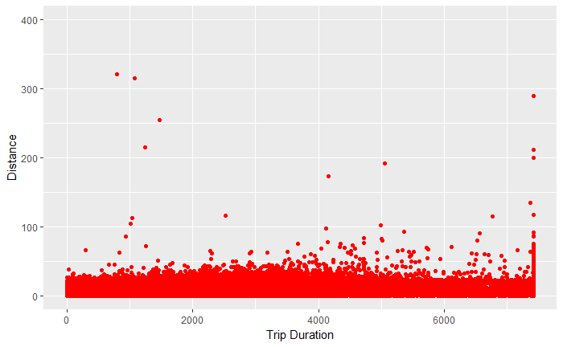

```r
dt<-ggplot() +
  geom_point(aes(x = datanew2$trip_duration, y = datanew2$distance),
             colour = 'red') +xlab("Trip Duration")+ylab("Distance")+labs(fill="Travelled")
dt + coord_cartesian(ylim= c(0,400))
```

Making a new dataframe

```r
temp<-datanew2[-(1:nrow(train))]
temp2<-datanew2[1:nrow(train)]
temp2<-temp2[which(temp2$distance<45)]
head(temp2)
```

| id | vendor_id | passenger_count | pickup_longitude | pickup_latitude | dropoff_longitude | dropoff_latitude | store_and_fwd_flag | trip_duration | pickup_date | time_day | distance |
| --- | --- | --- | --- | --- | --- | --- | --- | --- | --- | --- | --- |
| id2875421 | 2 | -0.5053459 | -0.120436644 | 0.5316598 | 0.123530135 | 0.3846506 | N | 1 | 2016-03-14 | E | 1.500199 |
| id2377394 | 1 | -0.5053459 | -0.096161271 | -0.3862121 | -0.365778132 | -0.5757616 | N | 2 | 2016-06-12 | LN | 1.807530 |
| id3858529 | 2 | -0.5053459 | -0.076783560 | 0.4067338 | -0.447936504 | -1.1630052 | N | 3 | 2016-01-19 | A | 6.392251 |
| id3504673 | 2 | -0.5053459 | -0.509587924 | -0.9672131 | -0.545305422 | -1.2569088 | N | 4 | 2016-04-06 | N | 1.487163 |
| id2181028 | 2 | -0.5053459 | 0.006583185 | 1.3213872 | 0.007094477 | 0.8562959 | N | 5 | 2016-03-26 | A | 1.189920 |
| id0801584 | 2 | 3.3016883 | -0.130231971 | -0.2727298 | -0.261875107 | -0.0730633 | N | 6 | 2016-01-30 | LN | 1.100174 |

```r
summary(temp2$distance)
```

```
   Min. 1st Qu.  Median    Mean 3rd Qu.    Max.
  0.000   1.233   2.096   3.436   3.879  44.970
```

We need to remove the 0 distance also and that is important,It is taken for a value that is greater than the zero .

```r
temp2<-temp2[which(temp2$distance>0)]
```

```r
summary(temp2$distance)
```

```
    Min.  1st Qu.   Median     Mean  3rd Qu.     Max.
 0.00042  1.24184  2.10493  3.44995  3.89162 44.96991
```

# Adding the velocity feature

with the help of distance and time we calculate the velocity feature abd this will be per hour that is why we multiply with 3600

```r
velocity <- (temp2[1:1452623,]$distance/temp2[1:1452623,]$trip_duration)
velocity <- velocity*3600
temp2$velocity <- velocity
```

```r
summary(temp2$velocity)
```

```
    Min.  1st Qu.   Median     Mean  3rd Qu.     Max.
    0.00     5.75    11.01    43.99    22.68 32880.18
```

As usual we have anomalies in the solution and that we have the fact we have to follow the rules and regulations of the of the NEW YORK driving authority i.e knowing the speed limit of the cabs in new york this will help remove the anomulous limits .

According to the driving authority the speed limit is 55 miles per hour converting it kms it is 90 kms per hour and minimum speed limit is considered to be 5 kms per hr.

```r
temp2<-temp2[which(temp2$velocity < 90)]
temp2<-temp2[!(temp2$velocity <5)]
head(temp2)
```

| id | vendor_id | passenger_count | pickup_longitude | pickup_latitude | dropoff_longitude | dropoff_latitude | store_and_fwd_flag | trip_duration | pickup_date | time_day | distance | velocity |
| --- | --- | --- | --- | --- | --- | --- | --- | --- | --- | --- | --- | --- |
| id2569332 | 1 | -0.5053459 | 0.06695221 | 1.1097999 | 0.1815873 | 0.7345295 | N | 54 | 2016-04-13 | A | 1.1542083 | 76.94722 |
| id0442192 | 1 | -0.5053459 | -0.45773658 | -0.5478530 | -0.3731692 | -0.2383252 | N | 64 | 2016-04-10 | E | 1.2205858 | 68.65795 |
| id0515898 | 2 | -0.5053459 | -0.40535288 | -0.3628481 | -0.2590901 | -0.1897250 | N | 65 | 2016-05-21 | E | 1.1016367 | 61.01373 |
| id1680350 | 1 | -0.5053459 | -0.41110231 | -0.8627903 | -0.3949138 | -0.6406328 | N | 68 | 2016-03-18 | N | 0.6253121 | 33.10476 |
| id2846400 | 2 | -0.5053459 | -0.33114263 | -1.0300337 | -0.3625646 | -0.6073465 | N | 71 | 2016-03-16 | N | 1.3528707 | 68.59626 |
| id1510700 | 2 | -0.5053459 | 0.21111386 | 0.6782809 | 0.2568902 | 0.6255247 | N | 72 | 2016-02-20 | N | 0.3287004 | 16.43502 |

```r
summary(temp2$velocity)
```

```
   Min. 1st Qu.  Median    Mean 3rd Qu.    Max.
  5.000   8.364  13.291  19.131  23.416  89.999
```

# Considering the practical timings

```r
temp2<-temp2[which(temp2$trip_duration > 60)]
temp2<-temp2[which(temp2$trip_duration < 7200)]
summary(temp2$trip_duration)
```

```
   Min. 1st Qu.  Median    Mean 3rd Qu.    Max.
   61.0   397.0   733.0   985.4  1334.0  7199.0
```

## Additional data (WEATHER DATA)

Since this is a playground challange , extra data is allowed to be added and so one of the best data that can be added is the temperature . As temperature can also affect the trip durtion in this it is likly to be a feature in this . I got this dataset from the kaggle website , it is the newyork 2016 dataset.

```r
library(readr)
weather <- read_csv("weatherdatanew1.csv")
head(weather)
```

| date | maximum temperature | minimum temperature | average temperature | precipitation | snow fall | snow depth |
| --- | --- | --- | --- | --- | --- | --- |
| 2016-01-01 | 42 | 34 | 38 | 0 | 0 | 0 |
| 2016-01-02 | 40 | 32 | 36 | 0 | 0 | 0 |
| 2016-01-03 | 45 | 35 | 40 | 0 | 0 | 0 |
| 2016-01-04 | 36 | 14 | 25 | 0 | 0 | 0 |
| 2016-01-05 | 29 | 11 | 20 | 0 | 0 | 0 |
| 2016-01-06 | 41 | 25 | 33 | 0 | 0 | 0 |

```r
summary(weather)
```

```
      date            maximum temperature minimum temperature average temperature
 Min.   :2016-01-01   Min.   :15.00       Min.   :-1.00       Min.   : 7.00
 1st Qu.:2016-04-01   1st Qu.:50.00       1st Qu.:37.25       1st Qu.:44.00
 Median :2016-07-01   Median :64.50       Median :48.00       Median :55.75
 Mean   :2016-07-01   Mean   :64.63       Mean   :49.81       Mean   :57.22
 3rd Qu.:2016-09-30   3rd Qu.:81.00       3rd Qu.:65.00       3rd Qu.:73.50
 Max.   :2016-12-31   Max.   :96.00       Max.   :81.00       Max.   :88.50
 precipitation       snow fall          snow depth
 Length:366         Length:366         Length:366
 Class :character   Class :character   Class :character
 Mode  :character   Mode  :character   Mode  :character
```

[output not shown]

Adding a rain feature

```r
rain = as.numeric(ifelse(weather$precipitation == "T", "0.01", weather$precipitation))
```

```r
weather$rain<-rain
weather$s_fall<-NULL
weather$allprecp<- NULL
weather$has_snow<- NULL
weather$has_rain<- NULL
weather$precipitation<-NULL
weather$`snow fall`<-NULL
weather$`snow depth`<-NULL
```

```r
head(weather)
```

| date | maximum temperature | minimum temperature | average temperature | rain |
| --- | --- | --- | --- | --- |
| 2016-01-01 | 42 | 34 | 38 | 0 |
| 2016-01-02 | 40 | 32 | 36 | 0 |
| 2016-01-03 | 45 | 35 | 40 | 0 |
| 2016-01-04 | 36 | 14 | 25 | 0 |
| 2016-01-05 | 29 | 11 | 20 | 0 |
| 2016-01-06 | 41 | 25 | 33 | 0 |

# Merging

Here we merge the two datasets , stemp2 and weather

```r
temp2$`snow fall`<-NULL
```

```
Adding new column 'snow fall' then assigning NULL (deleting it).
```

```r
temp2$`snow depth`<-NULL
```

```
Adding new column 'snow depth' then assigning NULL (deleting it).
```

```r
temp2$precipitation<-NULL
```

```
Adding new column 'precipitation' then assigning NULL (deleting it).
```

```r
head(temp2)
```

| date | id | vendor_id | passenger_count | pickup_longitude | pickup_latitude | dropoff_longitude | dropoff_latitude | store_and_fwd_flag | trip_duration | time_day | distance | velocity | maximum temperature | minimum temperature | average temperature | rain |
| --- | --- | --- | --- | --- | --- | --- | --- | --- | --- | --- | --- | --- | --- | --- | --- | --- |
| 2016-01-01 | id3620795 | 1 | -0.5053459 | -0.3919375 | -0.31600090 | -0.32003938 | -0.7220940 | N | 159 | M | 1.7206065 | 38.957129 | 42 | 34 | 38 | 0 |
| 2016-01-01 | id2336715 | 2 | 0.2560609 | -0.1512067 | -0.06054642 | -0.32089631 | -0.9965734 | N | 205 | LN | 3.8010933 | 66.750906 | 42 | 34 | 38 | 0 |
| 2016-01-01 | id0645865 | 2 | 0.2560609 | 0.2843659 | 1.27167911 | 0.07329249 | 1.2663667 | N | 376 | EM | 1.4146122 | 13.544160 | 42 | 34 | 38 | 0 |
| 2016-01-01 | id3806962 | 2 | 3.3016883 | -0.4443212 | -0.89318737 | -0.29861607 | -0.3252101 | N | 480 | E | 2.1761261 | 16.320946 | 42 | 34 | 38 | 0 |
| 2016-01-01 | id2987313 | 2 | -0.5053459 | -0.2867442 | 0.01121448 | -0.29293890 | 0.1873785 | N | 440 | M | 0.8066264 | 6.599671 | 42 | 34 | 38 | 0 |
| 2016-01-01 | id1527619 | 1 | -0.5053459 | -0.3188985 | -0.06519538 | -0.19235649 | -1.5120333 | N | 231 | EM | 5.7603673 | 89.771958 | 42 | 34 | 38 | 0 |

## Correlation of the features for removing predictors

This is one important preprocessing tool that helps the to know which all of the following columns are correlated . if they are closly correlated then we can use PCA (principle component analysis) on those features and then remove them from the and add up the pca array to the column in the temp2 dataframe .

since it works only for the numeric features we consider those .

```r
cntemp<-temp2
library(microbenchmark)
cntemp2<-Filter(is.numeric, cntemp)
cntemp2$`maximum temperature`<-NULL
cntemp2$`minimum temperature`<-NULL

cor(cntemp2)
M<-cor(cntemp2)
```

We now plot the correlation .

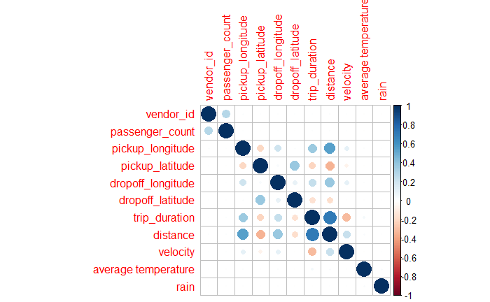

```r
library(corrplot)
corrplot(M, method = "circle")
```

To get a better idea lets do it with numbers rather than any other graph.

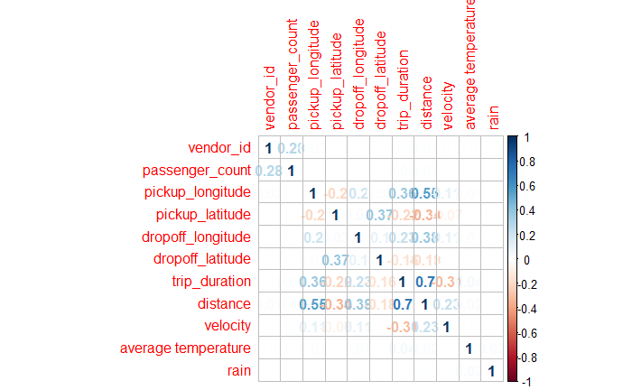

```r
corrplot(M, method = "number")
```

## Training the dataset

As the above I will be using ANN for the predictions .The activation function that I will be using is rectifier . As its derivative value is 1 . gradient decent on this is much effective .

```r
str(temp2)
```

```
Classes data.table and 'data.frame':  1071437 obs. of  17 variables:
 $ date               : chr  "2016-01-01" "2016-01-01" "2016-01-01" "2016-01-01" ...
 $ id                 : chr  "id3620795" "id2336715" "id0645865" "id3806962" ...
 $ vendor_id          : int  1 2 2 2 2 1 1 1 1 2 ...
 $ passenger_count    : atomic  -0.505 0.256 0.256 3.302 -0.505 ...
  ..- attr(*, "scaled:center")= num 1.66
  ..- attr(*, "scaled:scale")= num 1.31
 $ pickup_longitude   : atomic  -0.392 -0.151 0.284 -0.444 -0.287 ...
  ..- attr(*, "scaled:center")= num -74
  ..- attr(*, "scaled:scale")= num 0.0717
 $ pickup_latitude    : atomic  -0.316 -0.0605 1.2717 -0.8932 0.0112 ...
  ..- attr(*, "scaled:center")= num 40.8
  ..- attr(*, "scaled:scale")= num 0.032
 $ dropoff_longitude  : atomic  -0.32 -0.3209 0.0733 -0.2986 -0.2929 ...
  ..- attr(*, "scaled:center")= num -74
  ..- attr(*, "scaled:scale")= num 0.0712
 $ dropoff_latitude   : atomic  -0.722 -0.997 1.266 -0.325 0.187 ...
  ..- attr(*, "scaled:center")= num 40.8
  ..- attr(*, "scaled:scale")= num 0.0359
 $ store_and_fwd_flag : chr  "N" "N" "N" "N" ...
 $ trip_duration      : num  159 205 376 480 440 ...
 $ time_day           : chr  "M" "LN" "EM" "E" ...
 $ distance           : num  1.721 3.801 1.415 2.176 0.807 ...
 $ velocity           : num  39 66.8 13.5 16.3 6.6 ...
 $ maximum temperature: int  42 42 42 42 42 42 42 42 42 42 ...
 $ minimum temperature: int  34 34 34 34 34 34 34 34 34 34 ...
 $ average temperature: num  38 38 38 38 38 38 38 38 38 38 ...
 $ rain               : num  0 0 0 0 0 0 0 0 0 0 ...
 - attr(*, ".internal.selfref")=<externalptr>
 - attr(*, "sorted")= chr "date"
```

## Splitting of the dataset into taining and validation set

```r
library(caTools)
set.seed(123)
split = sample.split(temp2$trip_duration, SplitRatio = 0.8)
training_set = subset(temp2, split == TRUE)
test_set = subset(temp2, split == FALSE)
```

Trying with 100 nodes in 2 layers

First fixing the bias i.e the RMSE value that we have and get it as loer as possible for the training set and then move on to the test set and check on that . Usually the best ranges are between 60-128 nodes in case of this dataset.

```r
library(h2o)
h2o.init(nthreads = 3)
```

```
 Connection successful!

R is connected to the H2O cluster:
    H2O cluster uptime:         3 hours 14 minutes
    H2O cluster version:        3.16.0.2
    H2O cluster version age:    1 month and 22 days
    H2O cluster name:           H2O_started_from_R_Rishit_jad911
    H2O cluster total nodes:    1
    H2O cluster total memory:   1.48 GB
    H2O cluster total cores:    4
    H2O cluster allowed cores:  3
    H2O cluster healthy:        TRUE
    H2O Connection ip:          localhost
    H2O Connection port:        54321
    H2O Connection proxy:       NA
    H2O Internal Security:      FALSE
    H2O API Extensions:         Algos, AutoML, Core V3, Core V4
    R Version:                  R version 3.4.2 (2017-09-28)
```

```r
training_set$date<- as.Date(training_set$date)
train.h20<-as.h2o(training_set)
train.h20$vendor_id<-as.factor(train.h20$vendor_id)
train.h20$store_and_fwd_flag<-as.factor(train.h20$store_and_fwd_flag)
train.h20$time_day<-as.factor(train.h20$time_day)
model2 = h2o.deeplearning(x=c(3,4,5,6,7,8,9,11,12,13,16,17),y = 10,
                         training_frame = as.h2o(train.h20),
                         activation = 'Rectifier',
                         hidden = c(100,100),
                         epochs = 100
)
```

```r
print(model2)
```

```
Model Details:
==============

H2ORegressionModel: deeplearning
Model ID:  DeepLearning_model_R_1516532244811_1
Status of Neuron Layers: predicting trip_duration, regression, gaussian distribution, Quadratic loss, 12,501 weights/biases, 154.0 KB, 6,198,765 training samples, mini-batch size 1
  layer units      type dropout       l1       l2 mean_rate rate_rms momentum
1     1    22     Input  0.00 %
2     2   100 Rectifier  0.00 % 0.000000 0.000000  0.353418 0.376319 0.000000
3     3   100 Rectifier  0.00 % 0.000000 0.000000  0.497567 0.401660 0.000000
4     4     1    Linear         0.000000 0.000000  0.095674 0.184418 0.000000
  mean_weight weight_rms mean_bias bias_rms
1
2   -0.044275   0.263904  0.322478 0.332734
3   -0.039273   0.136322  0.888932 0.112403
4    0.039430   0.096209 -0.151186 0.000000


H2ORegressionMetrics: deeplearning
** Reported on training data. **
** Metrics reported on temporary training frame with 10026 samples **

MSE:  35.85898
RMSE:  5.988237
MAE:  4.103154
RMSLE:  0.0122235
Mean Residual Deviance :  35.85898
```

```r
library(h2o)
h2o.init(nthreads = 3)
```

```
 Connection successful!

R is connected to the H2O cluster:
    H2O cluster uptime:         3 hours 22 minutes
    H2O cluster version:        3.16.0.2
    H2O cluster version age:    1 month and 22 days
    H2O cluster name:           H2O_started_from_R_Rishit_jad911
    H2O cluster total nodes:    1
    H2O cluster total memory:   1.47 GB
    H2O cluster total cores:    4
    H2O cluster allowed cores:  3
    H2O cluster healthy:        TRUE
    H2O Connection ip:          localhost
    H2O Connection port:        54321
    H2O Connection proxy:       NA
    H2O Internal Security:      FALSE
    H2O API Extensions:         Algos, AutoML, Core V3, Core V4
    R Version:                  R version 3.4.2 (2017-09-28)
```

```r
training_set$date<- as.Date(training_set$date)
train.h20<-as.h2o(training_set)
train.h20$vendor_id<-as.factor(train.h20$vendor_id)
train.h20$store_and_fwd_flag<-as.factor(train.h20$store_and_fwd_flag)
train.h20$time_day<-as.factor(train.h20$time_day)
model = h2o.deeplearning(x=c(3,4,5,6,7,8,9,11,12,13,16,17),y = 10,
                         training_frame = as.h2o(train.h20),
                         activation = 'Rectifier',
                         hidden = c(90,90),
                         epochs = 100
)
```

```r
print(model)
```

```
Model Details:
==============

H2ORegressionModel: deeplearning
Model ID:  DeepLearning_model_R_1516532244811_3
Status of Neuron Layers: predicting trip_duration, regression, gaussian distribution, Quadratic loss, 10,351 weights/biases, 128.5 KB, 5,799,713 training samples, mini-batch size 1
  layer units      type dropout       l1       l2 mean_rate rate_rms momentum
1     1    22     Input  0.00 %
2     2    90 Rectifier  0.00 % 0.000000 0.000000  0.331184 0.370973 0.000000
3     3    90 Rectifier  0.00 % 0.000000 0.000000  0.426361 0.389721 0.000000
4     4     1    Linear         0.000000 0.000000  0.048640 0.090862 0.000000
  mean_weight weight_rms mean_bias bias_rms
1
2   -0.024460   0.220859  0.396030 0.265622
3   -0.037341   0.134179  0.931909 0.104199
4    0.047498   0.098143 -0.033137 0.000000


H2ORegressionMetrics: deeplearning
** Reported on training data. **
** Metrics reported on temporary training frame with 9994 samples **

MSE:  57.57892
RMSE:  7.588077
MAE:  4.970521
RMSLE:  0.01684209
Mean Residual Deviance :  57.57892
```

Trying with 110 nodes in each layer

```r
library(h2o)
h2o.init(nthreads = 3)
```

```
 Connection successful!

R is connected to the H2O cluster:
    H2O cluster uptime:         3 hours 17 minutes
    H2O cluster version:        3.16.0.2
    H2O cluster version age:    1 month and 22 days
    H2O cluster name:           H2O_started_from_R_Rishit_jad911
    H2O cluster total nodes:    1
    H2O cluster total memory:   1.50 GB
    H2O cluster total cores:    4
    H2O cluster allowed cores:  3
    H2O cluster healthy:        TRUE
    H2O Connection ip:          localhost
    H2O Connection port:        54321
    H2O Connection proxy:       NA
    H2O Internal Security:      FALSE
    H2O API Extensions:         Algos, AutoML, Core V3, Core V4
    R Version:                  R version 3.4.2 (2017-09-28)
```

```r
training_set$date<- as.Date(training_set$date)
train.h20<-as.h2o(training_set)
train.h20$vendor_id<-as.factor(train.h20$vendor_id)
train.h20$store_and_fwd_flag<-as.factor(train.h20$store_and_fwd_flag)
train.h20$time_day<-as.factor(train.h20$time_day)
model = h2o.deeplearning(x=c(3,4,5,6,7,8,9,11,12,13,16,17),y = 10,
                         training_frame = as.h2o(train.h20),
                         activation = 'Rectifier',
                         hidden = c(110,110),
                         epochs = 100

)
```

```r
print(model)
```

```
Model Details:
==============

H2ORegressionModel: deeplearning
Model ID:  DeepLearning_model_R_1516532244811_2
Status of Neuron Layers: predicting trip_duration, regression, gaussian distribution, Quadratic loss, 14,851 weights/biases, 181.8 KB, 6,998,033 training samples, mini-batch size 1
  layer units      type dropout       l1       l2 mean_rate rate_rms momentum
1     1    22     Input  0.00 %
2     2   110 Rectifier  0.00 % 0.000000 0.000000  0.334701 0.360331 0.000000
3     3   110 Rectifier  0.00 % 0.000000 0.000000  0.483644 0.403719 0.000000
4     4     1    Linear         0.000000 0.000000  0.131234 0.219641 0.000000
  mean_weight weight_rms mean_bias bias_rms
1
2   -0.033672   0.255112  0.324078 0.294950
3   -0.036591   0.133262  0.904500 0.123557
4    0.031598   0.092476 -0.217111 0.000000


H2ORegressionMetrics: deeplearning
** Reported on training data. **
** Metrics reported on temporary training frame with 9959 samples **

MSE:  42.36559
RMSE:  6.508885
MAE:  4.19417
RMSLE:  0.01236098
Mean Residual Deviance :  42.36559
```

# Predicting the validation set

```r
h2o.init(nthreads = 3)
```

```
 Connection successful!

R is connected to the H2O cluster:
    H2O cluster uptime:         3 hours 26 minutes
    H2O cluster version:        3.16.0.2
    H2O cluster version age:    1 month and 22 days
    H2O cluster name:           H2O_started_from_R_Rishit_jad911
    H2O cluster total nodes:    1
    H2O cluster total memory:   1.35 GB
    H2O cluster total cores:    4
    H2O cluster allowed cores:  3
    H2O cluster healthy:        TRUE
    H2O Connection ip:          localhost
    H2O Connection port:        54321
    H2O Connection proxy:       NA
    H2O Internal Security:      FALSE
    H2O API Extensions:         Algos, AutoML, Core V3, Core V4
    R Version:                  R version 3.4.2 (2017-09-28)
```

```r
test_set$trip_duration=as.numeric(test_set$trip_duration)
test.h20<-as.h2o(test_set)
test.h20$vendor_id<-as.factor(test.h20$vendor_id)
test.h20$store_and_fwd_flag<-as.factor(test.h20$store_and_fwd_flag)
test.h20$time_day<-as.factor(test.h20$time_day)
y_pred = h2o.predict(model2, newdata = as.h2o(test.h20))
y_pred= as.data.frame(y_pred)
```

```r
library(hydroGOF)
rmse(y_pred,test_set$trip_duration)
```

```
 predict
5.957601
```

# Variable importance in the graph

This is for the best model i obtained till now .

```r
library(h2o)
localH2O<-h2o.init(nthreads = 3)
```

```
 Connection successful!

R is connected to the H2O cluster:
    H2O cluster uptime:         3 hours 28 minutes
    H2O cluster version:        3.16.0.2
    H2O cluster version age:    1 month and 22 days
    H2O cluster name:           H2O_started_from_R_Rishit_jad911
    H2O cluster total nodes:    1
    H2O cluster total memory:   1.33 GB
    H2O cluster total cores:    4
    H2O cluster allowed cores:  3
    H2O cluster healthy:        TRUE
    H2O Connection ip:          localhost
    H2O Connection port:        54321
    H2O Connection proxy:       NA
    H2O Internal Security:      FALSE
    H2O API Extensions:         Algos, AutoML, Core V3, Core V4
    R Version:                  R version 3.4.2 (2017-09-28)
```

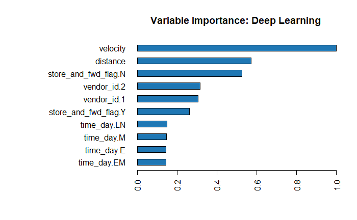

```r
h2o.varimp_plot(model2)
```

```r
library(h2o)
localH2O<-h2o.init(nthreads = 3)
```

```
 Connection successful!

R is connected to the H2O cluster:
    H2O cluster uptime:         3 hours 28 minutes
    H2O cluster version:        3.16.0.2
    H2O cluster version age:    1 month and 22 days
    H2O cluster name:           H2O_started_from_R_Rishit_jad911
    H2O cluster total nodes:    1
    H2O cluster total memory:   1.33 GB
    H2O cluster total cores:    4
    H2O cluster allowed cores:  3
    H2O cluster healthy:        TRUE
    H2O Connection ip:          localhost
    H2O Connection port:        54321
    H2O Connection proxy:       NA
    H2O Internal Security:      FALSE
    H2O API Extensions:         Algos, AutoML, Core V3, Core V4
    R Version:                  R version 3.4.2 (2017-09-28)
```

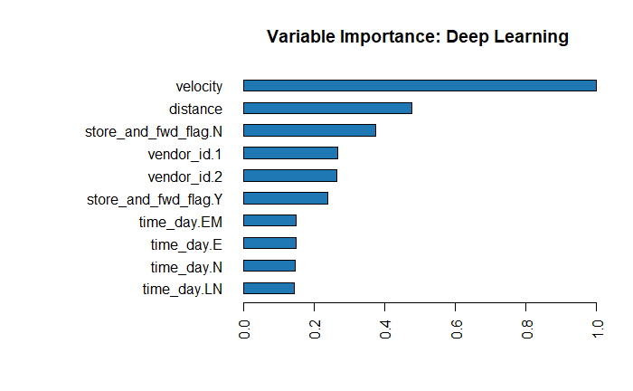

```r
h2o.varimp_plot(model)
```

## Final result of the ANN

An achievement of not over fitting .

# RMSE on training set = 5.98

# RMSE on validation set = 5.95

——————————————————THANK YOU for viewing—————————————————–